# Assignment - 2_Business Analytics

Spandana Sodadasi

2023-10-04

```r
knitr::opts_chunk$set(echo = TRUE, comment = NULL)
options(repr.matrix.max.rows=Inf, repr.matrix.max.cols=Inf)
```

#### Loading the required libraries.

```r
library(dplyr, warn.conflicts = FALSE)
```

#### Downloading the Online Retail dataset, and using the read.csv() command to load the file into a R dataframe.

```r
library(readr)
Online_Retail <- read.csv("C:/Users/spand/Downloads/Online_Retail (2).csv")
View(Online_Retail)
dim(Online_Retail)
```

```
[1] 541909      8
```

1.Show the breakdown of the number of transactions by countries i.e., how many transactions are in the dataset for each country (consider all records including cancelled transactions). Show this in total number and also in percentage. Show only countries accounting for more than 1% of the total transactions.

```r
summary(Online_Retail$Country)
```

```
   Length     Class      Mode
   541909 character character
```

```r
Country_totalnumber <- table(Online_Retail$Country)
Transaction_percent <- round(100*prop.table(Country_totalnumber), digits = 3)
Percentage <- cbind(Country_totalnumber,Transaction_percent)
Result <- as.data.frame(Percentage)
Result <- Result[Result$Transaction_percent > 1,]
print.AsIs(Result)
```

```
               Country_totalnumber Transaction_percent
EIRE                          8196               1.512
France                        8557               1.579
Germany                       9495               1.752
United Kingdom              495478              91.432
```

2.Create a new variable ‘TransactionValue’ that is the product of the exising ‘Quantity’ and ‘UnitPrice’ variables. Add this variable to the dataframe.

```r
Online_Retail <- Online_Retail %>% group_by(TransactionValue= Quantity * UnitPrice)
summary(Online_Retail$TransactionValue)
```

```
      Min.    1st Qu.     Median       Mean    3rd Qu.       Max.
-168469.60       3.40       9.75      17.99      17.40  168469.60
```

3.Using the newly created variable, TransactionValue, show the breakdown of transaction values by countries i.e. how much money in total has been spent each country. Show this in total sum of transaction values. Show only countries with total transaction exceeding 130,000 British Pound.

```r
summary(Online_Retail$TransactionValue)
```

```
      Min.    1st Qu.     Median       Mean    3rd Qu.       Max.
-168469.60       3.40       9.75      17.99      17.40  168469.60
```

```r
Country_totalnumber <- table(Online_Retail$TransactionValue)
Total_Transaction <- Online_Retail %>% group_by(Country) %>%
                     summarise(Total_sum = sum(TransactionValue)) %>%
                     filter(Total_sum > 130000)
print.AsIs(Total_Transaction)
```

```
         Country Total_sum
1      Australia  137077.3
2           EIRE  263276.8
3         France  197403.9
4        Germany  221698.2
5    Netherlands  284661.5
6 United Kingdom 8187806.4
```

4.This is an optional question which carries additional marks (golden questions). In this question, we are dealing with the InvoiceDate variable. The variable is read as a categorical when you read data from the file. Now we need to explicitly instruct R to interpret this as a Date variable.

```r
Temp=strptime(Online_Retail$InvoiceDate,format='%m/%d/%Y %H:%M',tz='GMT')
head(Temp)
```

```
[1] "2010-12-01 08:26:00 GMT" "2010-12-01 08:26:00 GMT"
[3] "2010-12-01 08:26:00 GMT" "2010-12-01 08:26:00 GMT"
[5] "2010-12-01 08:26:00 GMT" "2010-12-01 08:26:00 GMT"
```

```r
Online_Retail$New_Invoice_Date <- as.Date(Temp)
Online_Retail$New_Invoice_Date[20000]-Online_Retail$New_Invoice_Date[10]
```

```
Time difference of 8 days
```

```r
Online_Retail$Invoice_Day_Week= weekdays(Online_Retail$New_Invoice_Date)
Online_Retail$New_Invoice_Hour = as.numeric(format(Temp, "%H"))
Online_Retail$New_Invoice_Month = as.numeric(format(Temp, "%m"))
```

1. Show the percentage of transactions (by numbers) by days of the week.

```r
a<-summarise(group_by(Online_Retail,Invoice_Day_Week),
             Transaction_Value=length(unique(InvoiceNo)))
Answer <-a %>% mutate(transaction_percent = (Transaction_Value / sum(Transaction_Value)) * 100)
print.AsIs(Answer)
```

```
  Invoice_Day_Week Transaction_Value transaction_percent
1           Friday              4184            16.15444
2           Monday              4138            15.97683
3           Sunday              2381             9.19305
4         Thursday              5660            21.85328
5          Tuesday              4722            18.23166
6        Wednesday              4815            18.59073
```

2. Show the percentage of transactions (by transaction volume) by days of the week.

```r
b<-summarise(group_by(Online_Retail,Invoice_Day_Week),
             Transaction_Volume=sum(TransactionValue))
Answer <- b %>% mutate(percentage=(Transaction_Volume/sum(Transaction_Volume))*100)
print.AsIs(Answer)
```

```
  Invoice_Day_Week Transaction_Volume percentage
1           Friday          1540610.8  15.804787
2           Monday          1588609.4  16.297194
3           Sunday           805678.9   8.265282
4         Thursday          2112519.0  21.671867
5          Tuesday          1966182.8  20.170636
6        Wednesday          1734147.0  17.790232
```

3. Show the percentage of transactions (by transaction volume) by month of the year.

```r
c <-summarise(group_by(Online_Retail,New_Invoice_Month),
              Transaction_Volume=sum(TransactionValue))
Answer <-c %>% mutate(percentage=(Transaction_Volume/sum(Transaction_Volume))*100)
print.AsIs(Answer)
```

```
   New_Invoice_Month Transaction_Volume percentage
1                  1           560000.3   5.744919
2                  2           498062.6   5.109515
3                  3           683267.1   7.009487
4                  4           493207.1   5.059703
5                  5           723333.5   7.420519
6                  6           691123.1   7.090080
7                  7           681300.1   6.989308
8                  8           682680.5   7.003469
9                  9          1019687.6  10.460751
10                10          1070704.7  10.984123
11                11          1461756.2  14.995836
12                12          1182625.0  12.132290
```

4. What was the date with the highest number of transactions from Australia?

```r
Retail <- Online_Retail %>% mutate(TransactionValue= Quantity * UnitPrice)
d <- Retail %>% filter(Country == 'Australia') %>% group_by(New_Invoice_Date) %>%
     summarise(Highest_number=max(TransactionValue))
write.csv(d, "data.csv", row.names = FALSE)
print.AsIs(d)
```

```
   New_Invoice_Date Highest_number
1        2010-12-01          51.00
2        2010-12-08          71.40
3        2010-12-14          -6.25
4        2010-12-17         147.50
5        2011-01-06        1020.00
6        2011-01-10          81.60
7        2011-01-11          35.40
8        2011-01-14         141.60
9        2011-01-17          47.40
10       2011-01-19          38.25
11       2011-01-20          26.85
12       2011-01-28          34.00
13       2011-02-07          53.10
14       2011-02-15         700.80
```

[output cut: 35 more lines]

5.Plot the histogram of transaction values from Germany. Use the hist() function to plot.

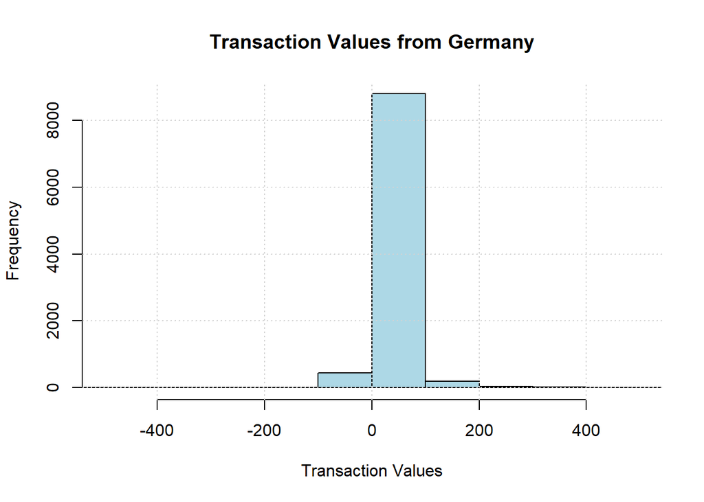

```r
Germany_Plot <- Online_Retail %>% filter(Country == "Germany") %>% select(TransactionValue)
hist(Germany_Plot$TransactionValue, xlab = "Transaction Values",
     main = "Transaction Values from Germany",xlim = c(-500, 500),
     col = "lightblue", border = "black", ylab = "Frequency")
grid()
```

6.Which customer had the highest number of transactions? Which customer is most valuable (i.e. highest total sum of transactions)?

```r
OnlineRetail <- na.omit(Online_Retail)
result1 <- OnlineRetail %>% group_by(CustomerID) %>% summarise(Highest_sum = sum(TransactionValue))
result1[which.max(result1$Highest_sum),]
```

```
# A tibble: 1 × 2
  CustomerID Highest_sum
       <int>       <dbl>
1      14646     279489.
```

```r
part2 <- table(Online_Retail$CustomerID)
part2 <- as.data.frame(part2)
part2[which.max(part2$Freq),]
```

```
      Var1 Freq
4043 17841 7983
```

7.Calculate the percentage of missing values for each variable in the dataset.

```r
colMeans(is.na(Online_Retail)*100)
```

```
        InvoiceNo         StockCode       Description          Quantity
          0.00000           0.00000           0.00000           0.00000
      InvoiceDate         UnitPrice        CustomerID           Country
          0.00000           0.00000          24.92669           0.00000
 TransactionValue  New_Invoice_Date  Invoice_Day_Week  New_Invoice_Hour
          0.00000           0.00000           0.00000           0.00000
New_Invoice_Month
          0.00000
```

8.What are the number of transactions with missing CustomerID records by countries?

```r
Retail2 <- Online_Retail %>% filter(is.na(CustomerID)) %>% group_by(Country)
summary(Retail2$Country)
```

```
   Length     Class      Mode
   135080 character character
```

9.On average, how often the customers comeback to the website for their next shopping? (i.e. what is the average number of days between consecutive shopping)

```r
Consecutive_days <- Online_Retail %>% arrange(CustomerID, InvoiceDate)
Consecutive_days$InvoiceDate <- as.Date(Consecutive_days$InvoiceDate, format = "%m/%d/%Y")
Consecutive_days <- Consecutive_days %>%  group_by(CustomerID) %>%
                 mutate(DaysBetween = c(0,diff(InvoiceDate)))
AverageDaysBetweenVisits <- mean(Consecutive_days$DaysBetween, na.rm = TRUE)
cat(round(AverageDaysBetweenVisits, 2), "days.")
```

```
0.18 days.
```

10.In the retail sector, it is very important to understand the return rate of the goods purchased by customers. In this example, we can define this quantity, simply, as the ratio of the number of transactions cancelled (regardless of the transaction value) over the total number of transactions. With this definition, what is the return rate for the French customers?

```r
Retail_table <- filter(Online_Retail,Country=="France")
nrow(Retail_table)
```

```
[1] 8557
```

```r
Cancelled<-nrow(subset(Retail_table,TransactionValue<0))
print(Cancelled)
```

```
[1] 149
```

```r
Return_Rate=(Cancelled/8557)
Return_Rate
```

```
[1] 0.01741264
```

11.What is the product that has generated the highest revenue for the retailer? (i.e. item with the highest total sum of ‘TransactionValue’)

```r
Highest_sum <- Online_Retail %>% group_by(StockCode) %>%
               summarise(Total = sum(TransactionValue)) %>% filter(Total == max(Total))
print.AsIs(Highest_sum)
```

```
  StockCode    Total
1       DOT 206245.5
```

12.How many unique customers are represented in the dataset?

```r
unique_customers <- unique(Online_Retail$CustomerID)
length(unique_customers)
```

```
[1] 4373
```